```python
import pandas as pd
import numpy as np
from collections import Counter
from sklearn.metrics import confusion_matrix, accuracy_score
from sklearn.model_selection import KFold
import matplotlib.pyplot as plt
from sklearn.model_selection import train_test_split
```

# Data Preparation

According to the file abalone.names provided, this dataset is related to predicting the age of abalone from physical measurements. The age of abalone is determined by cutting the shell through the cone, staining it, and counting the number of rings through a microscope. The number of rings is the value to predict either as a continuous value or as a classification problem. The dataset has 8 features (excluding the target, "Rings"). Only the feature "Sex" is the categorical one. Other features are numerical.

Class Distribution:

```
Class   Examples
-----   --------
1   1
2   1
3   15
4   57
5   115
6   259
7   391
8   568
9   689
10  634
11  487
12  267
13  203
14  126
15  103
16  67
17  58
18  42
19  32
20  26
21  14
22  6
23  9
24  2
25  1
26  1
27  2
29  1
-----   ----
Total   4177
```

We can see that there is a class imbalance problem and this will affect the accuracy of the model as well. There will be a tendency to predict the most common classes. Therefore, I will show two different scenarios for this dataset.

```python
column_names = ['Sex', 'Length', 'Diameter', 'Height', 'Whole weight', 'Shucked weight', 'Viscera weight', 'Shell weight', 'Rings']

# Read the dataset
abalone = pd.read_csv("abalone/abalone.data", header=None, names=column_names)

abalone.head()
```

|  | Sex | Length | Diameter | Height | Whole weight | Shucked weight | Viscera weight | Shell weight | Rings |
| --- | --- | --- | --- | --- | --- | --- | --- | --- | --- |
| 0 | M | 0.455 | 0.365 | 0.095 | 0.5140 | 0.2245 | 0.1010 | 0.150 | 15 |
| 1 | M | 0.350 | 0.265 | 0.090 | 0.2255 | 0.0995 | 0.0485 | 0.070 | 7 |
| 2 | F | 0.530 | 0.420 | 0.135 | 0.6770 | 0.2565 | 0.1415 | 0.210 | 9 |
| 3 | M | 0.440 | 0.365 | 0.125 | 0.5160 | 0.2155 | 0.1140 | 0.155 | 10 |
| 4 | I | 0.330 | 0.255 | 0.080 | 0.2050 | 0.0895 | 0.0395 | 0.055 | 7 |

```python
abalone.info()
```

```
<class 'pandas.core.frame.DataFrame'>
RangeIndex: 4177 entries, 0 to 4176
Data columns (total 9 columns):
 #   Column          Non-Null Count  Dtype
---  ------          --------------  -----
 0   Sex             4177 non-null   object
 1   Length          4177 non-null   float64
 2   Diameter        4177 non-null   float64
 3   Height          4177 non-null   float64
 4   Whole weight    4177 non-null   float64
 5   Shucked weight  4177 non-null   float64
 6   Viscera weight  4177 non-null   float64
 7   Shell weight    4177 non-null   float64
 8   Rings           4177 non-null   int64
dtypes: float64(7), int64(1), object(1)
memory usage: 293.8+ KB
```

It doesn't have any null value. There is no need to handle missing values. Since our model is a decision tree, there is no need to convert categorical feature into numerical as well.

```python
abalone.describe()
```

|  | Length | Diameter | Height | Whole weight | Shucked weight | Viscera weight | Shell weight | Rings |
| --- | --- | --- | --- | --- | --- | --- | --- | --- |
| count | 4177.000000 | 4177.000000 | 4177.000000 | 4177.000000 | 4177.000000 | 4177.000000 | 4177.000000 | 4177.000000 |
| mean | 0.523992 | 0.407881 | 0.139516 | 0.828742 | 0.359367 | 0.180594 | 0.238831 | 9.933684 |
| std | 0.120093 | 0.099240 | 0.041827 | 0.490389 | 0.221963 | 0.109614 | 0.139203 | 3.224169 |
| min | 0.075000 | 0.055000 | 0.000000 | 0.002000 | 0.001000 | 0.000500 | 0.001500 | 1.000000 |
| 25% | 0.450000 | 0.350000 | 0.115000 | 0.441500 | 0.186000 | 0.093500 | 0.130000 | 8.000000 |
| 50% | 0.545000 | 0.425000 | 0.140000 | 0.799500 | 0.336000 | 0.171000 | 0.234000 | 9.000000 |
| 75% | 0.615000 | 0.480000 | 0.165000 | 1.153000 | 0.502000 | 0.253000 | 0.329000 | 11.000000 |
| max | 0.815000 | 0.650000 | 1.130000 | 2.825500 | 1.488000 | 0.760000 | 1.005000 | 29.000000 |

We need to have a feature/attribute vector to indicate the type of each attribute.

```python
# get the attribute types for each one
attribute_types = []

# iterate over each feature column in the DataFrame (excluding the class label, Rings)
for col in abalone.columns[:-1]:
    # check the data type of the column
    if abalone[col].dtype in [np.float64, np.int64]:
        attribute_types.append(1)  # Type 1: Numeric
    else:
        attribute_types.append(2)  # Type 2: Categorical

print("\nAttribute types (1: numeric, 2: categorical):")
print(attribute_types)
```

```
Attribute types (1: numeric, 2: categorical):
[2, 1, 1, 1, 1, 1, 1, 1]
```

# Use the Original Dataset Labels

This part uses the original dataset labels as 1-29 classes. This will give a low accuracy.

Get X and y to use them as parameters and split as train and test (for post-pruning), and convert them to numpy array

```python
X = abalone[abalone.columns[:-1]]
y = abalone.Rings

X_train, X_val, y_train, y_val = train_test_split(
        X, y, test_size=0.1, random_state=42
    )

X_train_numpy = X_train.values
y_train_numpy = y_train.values
X_val_numpy = X_val.values
y_val_numpy = y_val.values
```

# Decision Tree

This part is based on a video from AssemblyAI (https://youtu.be/NxEHSAfFlK8?si=2nylevP-THRv1B10), It handles the categorical features separately.

Pruning options are added.

None = there is no pruning.

1 = it will pre-prune tree.

2 = it will post-prune tree which also require a validation set.

```python
# Node class of the decision tree
class Node:
    def __init__(self, feature=None, threshold=None, left=None, right=None,*,value=None):
        self.feature = feature # the chosen feature
        self.threshold = threshold # the chosen threshold
        self.left = left # the left tree
        self.right = right # the right tree
        self.value = value # the class label

    def is_leaf_node(self):
        return self.value is not None

# Decision Tree class
class DecisionTree:
    def __init__(self, max_depth=None, pruning=None, n_features=None):
        self.min_samples_split=2 # the minimum sample number to split
        self.max_depth=max_depth # max depth for pre-pruning
        self.pruning=pruning # pruning type : None, 1 (pre), 2 (post)
        self.n_features=n_features # number of features as percentage (for random forest)
        self.root=None

    def fit(self, X, y, attribute_types, X_val, y_val):
        self.n_features = X.shape[1] if not self.n_features else min(X.shape[1],int((self.n_features*X.shape[1])/100))
        print(f"Number of features: {self.n_features}")
        self.root = self._grow_tree(X, y, attribute_types)

        # post-prune the tree
        if self.pruning == 2:
            self._post_prune(self.root, X_val, y_val)

    def _grow_tree(self, X, y, attribute_types, depth=0):
        n_samples, n_feats = X.shape
        n_labels = len(np.unique(y))

        # check the stopping criteria
        if self.pruning == None or self.pruning == 2:
            if (n_labels==1 or n_samples<self.min_samples_split):
                leaf_value = self._most_common_label(y)
                return Node(value=leaf_value)
        else: # additionally, check the depth for pre-pruning
            if (depth>=self.max_depth or n_labels==1 or n_samples<self.min_samples_split):
                leaf_value = self._most_common_label(y)
                return Node(value=leaf_value)

        # get features (for random forest)
        feat_idxs = np.random.choice(n_feats, self.n_features, replace=False)

        # find the best split
        best_feature, best_thresh = self._best_split(X, y, feat_idxs, attribute_types)

        # create child nodes
        if attribute_types[best_feature] == 2:  # 2 indicates a categorical feature
            left_idxs, right_idxs = self._split_categorical(X[:, best_feature], best_thresh)
        else:
            left_idxs, right_idxs = self._split(X[:, best_feature], best_thresh)

        # handle empty splits
        if len(left_idxs) == 0 or len(right_idxs) == 0:
            # return a leaf node with the most common label in y
            leaf_value = self._most_common_label(y)
            return Node(value=leaf_value)

        left = self._grow_tree(X[left_idxs, :], y[left_idxs], attribute_types, depth+1)
        right = self._grow_tree(X[right_idxs, :], y[right_idxs], attribute_types, depth+1)

        return Node(best_feature, best_thresh, left, right)


    def _best_split(self, X, y, feat_idxs, attribute_types):
        # find the best split by using information gain
        best_gain = -float('inf')
        split_idx, split_threshold = None, None

        for feat_idx in feat_idxs:
            X_column = X[:, feat_idx]
            thresholds = np.unique(X_column)

            for thr in thresholds:
                # calculate the information gain for the given attribute and threshold
                gain = self._information_gain(y, X_column, thr, attribute_types[feat_idx])
                if gain > best_gain:
                    best_gain = gain
                    split_idx = feat_idx
                    split_threshold = thr

        return split_idx, split_threshold


    def _information_gain(self, y, X_column, threshold, attribute_type):
        # parent entropy
        parent_entropy = self._entropy(y)

        # split the data based on whether the feature is categorical or numerical
        if attribute_type == 2:
            left_idxs, right_idxs = self._split_categorical(X_column, threshold)
        else:
            left_idxs, right_idxs = self._split(X_column, threshold)

        if len(left_idxs) == 0 or len(right_idxs) == 0:
            return 0

        # calculate the weighted avg. entropy of children
        n = len(y)
        n_l, n_r = len(left_idxs), len(right_idxs)
        e_l, e_r = self._entropy(y[left_idxs]), self._entropy(y[right_idxs])
        child_entropy = (n_l/n) * e_l + (n_r/n) * e_r

        # calculate the IG
        information_gain = parent_entropy - child_entropy

        return information_gain

    def _split(self, X_column, split_thresh):
        left_idxs = np.argwhere(X_column <= split_thresh).flatten()
        right_idxs = np.argwhere(X_column > split_thresh).flatten()

        return left_idxs, right_idxs

    def _split_categorical(self, X_column, category):
        left_idxs = np.argwhere(X_column == category).flatten()
        right_idxs = np.argwhere(X_column != category).flatten()

        return left_idxs, right_idxs

    def _entropy(self, y):
        hist = np.bincount(y)
        ps = hist / len(y)
        return -np.sum([p * np.log(p) for p in ps if p>0])


    def _most_common_label(self, y):
        counter = Counter(y)
        value = counter.most_common(1)[0][0]
        return value

    def predict(self, X):
        return np.array([self._traverse_tree(x, self.root) for x in X])

    def _traverse_tree(self, x, node):
        if node.is_leaf_node():
            return node.value

        if x[node.feature] <= node.threshold:
            return self._traverse_tree(x, node.left)
        return self._traverse_tree(x, node.right)


    def _post_prune(self, node, X_val, y_val):
        # recursively traverse the tree and prune nodes
        if not node.is_leaf_node():
            # prune left and right children first
            self._post_prune(node.left, X_val, y_val)
            self._post_prune(node.right, X_val, y_val)

            # calculate the performance metric before pruning
            pre_prune_metric = self._calculate_metric(X_val, y_val)

            # temporarily replace the current node with a leaf node using the most common label
            leaf_value = self._most_common_label(y_val)
            original_left = node.left
            original_right = node.right
            node.left = node.right = None
            node.value = leaf_value

            # calculate the performance metric after pruning
            post_prune_metric = self._calculate_metric(X_val, y_val)

            # if the performance metric has decreased after pruning, revert the changes
            if post_prune_metric < pre_prune_metric:
                node.value = None
                node.left = original_left
                node.right = original_right

    def _calculate_metric(self, X_val, y_val):
        # calculate a performance metric on the validation set
        y_pred = self.predict(X_val)
        metric = accuracy_score(y_val, y_pred)  # Use accuracy
        return metric
```

Option for build_dt includes pruning type, max depth, number of features, validation set as X and y respectively.

```python
def build_dt(X, y, attribute_types, options):
    pruning, max_depth, n_features, X_val, y_val = options # get the options in this order
    dt = DecisionTree(max_depth=max_depth, pruning=pruning, n_features=n_features) # create a decision tree
    dt.fit(X, y, attribute_types, X_val, y_val) # and get the trained tree

    return dt
```

```python
def predict_dt(dt, X, options=None):
    predictions = dt.predict(X)
    return predictions
```

Test with no pruning using 5-fold

```
Number of features: 8
Fold 1 is completed
Number of features: 8
Fold 2 is completed
Number of features: 8
Fold 3 is completed
Number of features: 8
Fold 4 is completed
Number of features: 8
Fold 5 is completed
Average Accuracy: 0.20
```

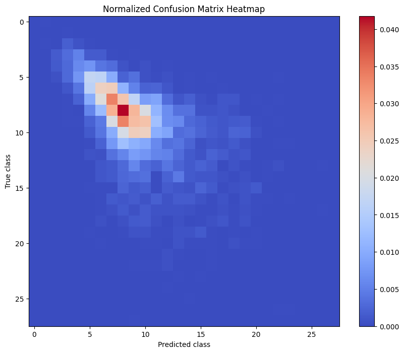

```python
kf = KFold(n_splits=5, shuffle=True, random_state=42)

# initialize performance metrics
accuracies = []
confusion_matrices = []
count = 1

# iterate over each fold
for train_index, test_index in kf.split(X_train_numpy, y_train_numpy):
    # split data into training and testing sets
    X_train, X_test = X_train_numpy[train_index], X_train_numpy[test_index]
    y_train, y_test = y_train_numpy[train_index], y_train_numpy[test_index]

    # create a decision tree and build
    dt = build_dt(X_train, y_train, attribute_types, options=(None, None, None, None, None))

    # make predictions on the test set
    y_pred = predict_dt(dt, X_test)

    # calculate accuracy
    accuracy = accuracy_score(y_test, y_pred)
    accuracies.append(accuracy)

    # calculate confusion matrix
    conf_matrix = confusion_matrix(y_test, y_pred, labels=np.unique(np.array(y)))
    confusion_matrices.append(conf_matrix)

    print(f"Fold {count} is completed")
    count += 1


# calculate average accuracy
average_accuracy = np.mean(accuracies)

# calculate average confusion matrix and normalized version
average_conf_matrix = np.mean(confusion_matrices, axis=0)

normalized_conf_matrix = average_conf_matrix / np.sum(average_conf_matrix)

# print the result
print(f'Average Accuracy: {average_accuracy:.2f}')

# create a heatmap for the normalized confusion matrix
plt.figure(figsize=(10, 8))

cmap = plt.get_cmap('coolwarm')
heatmap = plt.imshow(normalized_conf_matrix, cmap=cmap)
plt.colorbar(heatmap)
plt.xlabel('Predicted class')
plt.ylabel('True class')
plt.title('Normalized Confusion Matrix Heatmap')

# show the plot
plt.show()
```

We can see that the most accurate part is where the dataset has the most data entries. This is because there is a class imbalance. Therefore, it decreases the accuracy.

Test with pre-pruning using 5-fold, max depth is 5.

```
Number of features: 8
Fold 1 is completed
Number of features: 8
Fold 2 is completed
Number of features: 8
Fold 3 is completed
Number of features: 8
Fold 4 is completed
Number of features: 8
Fold 5 is completed
Average Accuracy: 0.26
```

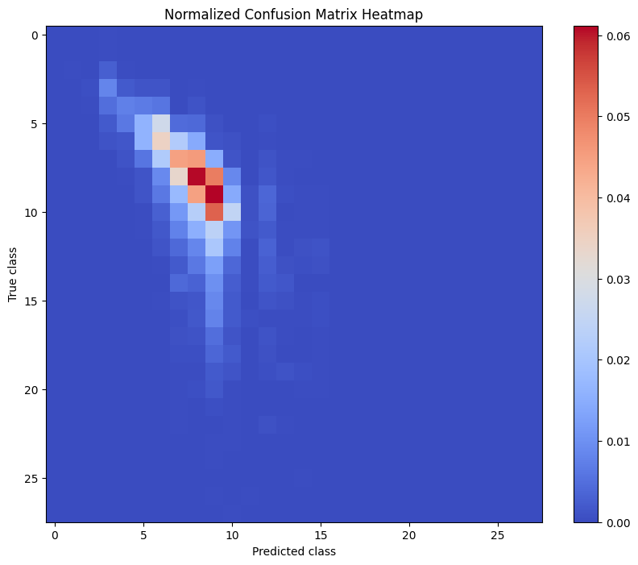

```python
kf = KFold(n_splits=5, shuffle=True, random_state=42)

# initialize performance metrics
accuracies = []
confusion_matrices = []
count = 1

# iterate over each fold
for train_index, test_index in kf.split(X_train_numpy, y_train_numpy):
    # split data into training and testing sets
    X_train, X_test = X_train_numpy[train_index], X_train_numpy[test_index]
    y_train, y_test = y_train_numpy[train_index], y_train_numpy[test_index]

    # create a decision tree and build
    dt = build_dt(X_train, y_train, attribute_types, options=(1, 5, None, None, None))

    # make predictions on the test set
    y_pred = predict_dt(dt, X_test)

    # calculate accuracy
    accuracy = accuracy_score(y_test, y_pred)
    accuracies.append(accuracy)

    # calculate confusion matrix
    conf_matrix = confusion_matrix(y_test, y_pred, labels=np.unique(np.array(y)))
    confusion_matrices.append(conf_matrix)

    print(f"Fold {count} is completed")
    count += 1


# calculate average accuracy
average_accuracy = np.mean(accuracies)

# calculate average confusion matrix and normalized version
average_conf_matrix = np.mean(confusion_matrices, axis=0)

normalized_conf_matrix = average_conf_matrix / np.sum(average_conf_matrix)

# print the result
print(f'Average Accuracy: {average_accuracy:.2f}')

# create a heatmap for the normalized confusion matrix
plt.figure(figsize=(10, 8))

cmap = plt.get_cmap('coolwarm')
heatmap = plt.imshow(normalized_conf_matrix, cmap=cmap)
plt.colorbar(heatmap)
plt.xlabel('Predicted class')
plt.ylabel('True class')
plt.title('Normalized Confusion Matrix Heatmap')

# show the plot
plt.show()
```

Pre-pruning gives more accurate result than no pruning since pruning prevents overfitting and this increases the accuracy of the model. The effect of class imbalance is still visible.

Test with post-pruning using 5-fold. It will use the validation set to prune.

```
Number of features: 8
Fold 1 is completed
Number of features: 8
Fold 2 is completed
Number of features: 8
Fold 3 is completed
Number of features: 8
Fold 4 is completed
Number of features: 8
Fold 5 is completed
Average Accuracy: 0.18
```

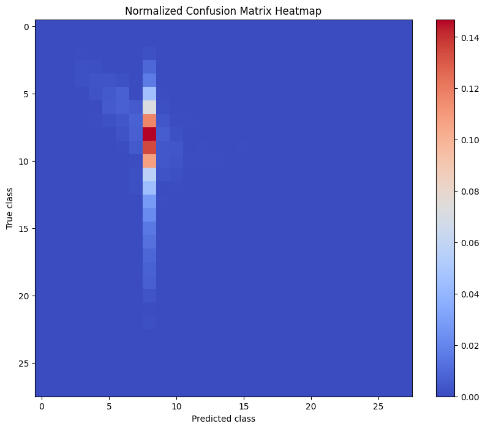

```python
kf = KFold(n_splits=5, shuffle=True, random_state=42)

# initialize performance metrics
accuracies = []
confusion_matrices = []
count = 1

# iterate over each fold
for train_index, test_index in kf.split(X_train_numpy, y_train_numpy):
    # split data into training and testing sets
    X_train, X_test = X_train_numpy[train_index], X_train_numpy[test_index]
    y_train, y_test = y_train_numpy[train_index], y_train_numpy[test_index]

    # create a decision tree and build
    dt = build_dt(X_train, y_train, attribute_types, options=(2, None, None, X_val_numpy, y_val_numpy))

    # make predictions on the test set
    y_pred = predict_dt(dt, X_test)

    # calculate accuracy
    accuracy = accuracy_score(y_test, y_pred)
    accuracies.append(accuracy)

    # calculate confusion matrix
    conf_matrix = confusion_matrix(y_test, y_pred, labels=np.unique(np.array(y)))
    confusion_matrices.append(conf_matrix)

    print(f"Fold {count} is completed")
    count += 1


# calculate average accuracy
average_accuracy = np.mean(accuracies)

# calculate average confusion matrix and normalized version
average_conf_matrix = np.mean(confusion_matrices, axis=0)

normalized_conf_matrix = average_conf_matrix / np.sum(average_conf_matrix)

# print the result
print(f'Average Accuracy: {average_accuracy:.2f}')

# create a heatmap for the normalized confusion matrix
plt.figure(figsize=(10, 8))

cmap = plt.get_cmap('coolwarm')
heatmap = plt.imshow(normalized_conf_matrix, cmap=cmap)
plt.colorbar(heatmap)
plt.xlabel('Predicted class')
plt.ylabel('True class')
plt.title('Normalized Confusion Matrix Heatmap')

# show the plot
plt.show()
```

Post-pruning doesn't give a great result as pre-pruning gives. This depends on the validation set size and the implementation of post-pruning. For this code, it doesn't produce a good result.

# Random Forest

This part is based on the next video of AssemblyAI (https://youtu.be/kFwe2ZZU7yw?si=nbaoIU69356_5z0B). DTs are built as fully grown as default.

```python
class RandomForest:
    def __init__(self, n_trees=10, n_features=None):
        self.n_trees = n_trees # number of trees
        self.n_features=n_features # number of features as percentage
        self.trees = []

    def fit(self, X, y):
        self.trees = []
        for _ in range(self.n_trees):
            X_sample, y_sample = self._bootstrap_samples(X, y) # get a bootstrap sample for the tree
            tree = build_dt(X_sample, y_sample, attribute_types, options=(None, None, self.n_features, None, None)) # build the tree
            self.trees.append(tree)

    def _bootstrap_samples(self, X, y):
        n_samples = X.shape[0]
        idxs = np.random.choice(n_samples, n_samples, replace=True)
        return X[idxs], y[idxs]

    def _most_common_label(self, y):
        counter = Counter(y)
        most_common = counter.most_common(1)[0][0]
        return most_common

    def predict(self, X):
        predictions = np.array([tree.predict(X) for tree in self.trees])
        tree_preds = np.swapaxes(predictions, 0, 1)
        predictions = np.array([self._most_common_label(pred) for pred in tree_preds])
        return predictions
```

Option for build_rdf is number of features as percentage. It also needs number of trees to build.

```python
def build_rdf(X, y, attribute_types, N, options):
    n_features = options # random forest only needs the number of features and number of trees
    rdf = RandomForest(n_trees=N, n_features=n_features)
    rdf.fit(X, y)
    return rdf
```

```python
def predict_rdf(rdf, X, options=None):
    predictions = rdf.predict(X)
    return predictions
```

Test with 5-fold. Number of feature is 30%. Number of trees is 10

```
Number of features: 2
Number of features: 2
Number of features: 2
Number of features: 2
Number of features: 2
Number of features: 2
Number of features: 2
Number of features: 2
Number of features: 2
Number of features: 2
Fold 1 is completed
Number of features: 2
Number of features: 2
Number of features: 2
Number of features: 2
Number of features: 2
Number of features: 2
Number of features: 2
Number of features: 2
Number of features: 2
Number of features: 2
Fold 2 is completed
Number of features: 2
Number of features: 2
Number of features: 2
Number of features: 2
Number of features: 2
Number of features: 2
Number of features: 2
Number of features: 2
Number of features: 2
Number of features: 2
Fold 3 is completed
Number of features: 2
Number of features: 2
Number of features: 2
Number of features: 2
Number of features: 2
Number of features: 2
Number of features: 2
Number of features: 2
Number of features: 2
Number of features: 2
Fold 4 is completed
Number of features: 2
Number of features: 2
Number of features: 2
Number of features: 2
Number of features: 2
Number of features: 2
Number of features: 2
Number of features: 2
Number of features: 2
Number of features: 2
Fold 5 is completed
Average Accuracy: 0.23
```

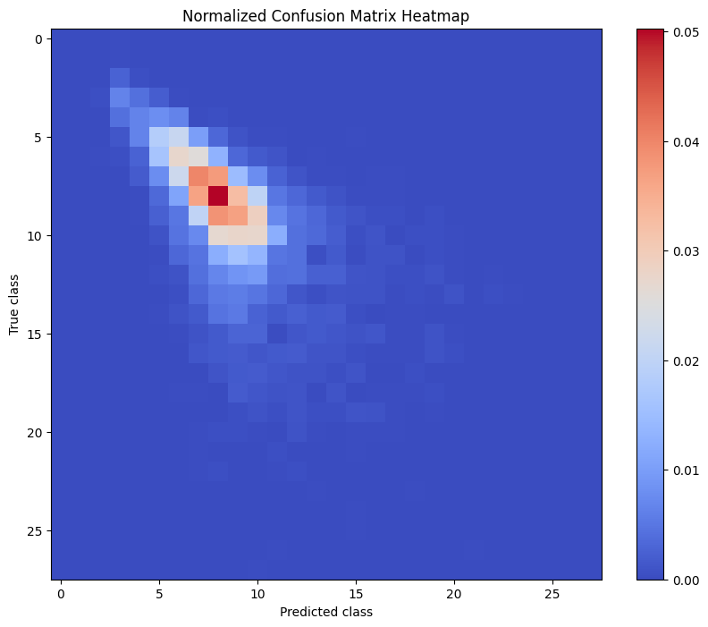

```python
kf = KFold(n_splits=5, shuffle=True, random_state=42)

# initialize performance metrics
accuracies = []
confusion_matrices = []
count = 1

N = 10
n_features = 30

# iterate over each fold
for train_index, test_index in kf.split(X_train_numpy, y_train_numpy):
    # split data into training and testing sets
    X_train, X_test = X_train_numpy[train_index], X_train_numpy[test_index]
    y_train, y_test = y_train_numpy[train_index], y_train_numpy[test_index]

    # build random forest
    rdf = build_rdf(X_train, y_train, attribute_types, N, options=n_features)

    # make predictions on the test set
    y_pred = predict_rdf(rdf, X_test)

    # calculate accuracy
    accuracy = accuracy_score(y_test, y_pred)
    accuracies.append(accuracy)

    # calculate confusion matrix
    conf_matrix = confusion_matrix(y_test, y_pred, labels=np.unique(np.array(y)))
    confusion_matrices.append(conf_matrix)

    print(f"Fold {count} is completed")
    count += 1



# calculate average accuracy
average_accuracy = np.mean(accuracies)

# calculate average confusion matrix and normalized version
average_conf_matrix = np.mean(confusion_matrices, axis=0)

normalized_conf_matrix = average_conf_matrix / np.sum(average_conf_matrix)

# print the result
print(f'Average Accuracy: {average_accuracy:.2f}')

# create a heatmap for the normalized confusion matrix
plt.figure(figsize=(10, 8))

cmap = plt.get_cmap('coolwarm')
heatmap = plt.imshow(normalized_conf_matrix, cmap=cmap)
plt.colorbar(heatmap)
plt.xlabel('Predicted class')
plt.ylabel('True class')
plt.title('Normalized Confusion Matrix Heatmap')

# show the plot
plt.show()
```

Using random forest doesn't increase the model accuracy that much since the main problem is caused by class imbalance.

Test with 5-fold. Number of feature is 30%. Number of trees is 5

```
Number of features: 2
Number of features: 2
Number of features: 2
Number of features: 2
Number of features: 2
Fold 1 is completed
Number of features: 2
Number of features: 2
Number of features: 2
Number of features: 2
Number of features: 2
Fold 2 is completed
Number of features: 2
Number of features: 2
Number of features: 2
Number of features: 2
Number of features: 2
Fold 3 is completed
Number of features: 2
Number of features: 2
Number of features: 2
Number of features: 2
Number of features: 2
Fold 4 is completed
Number of features: 2
Number of features: 2
Number of features: 2
Number of features: 2
Number of features: 2
Fold 5 is completed
Average Accuracy: 0.21
```

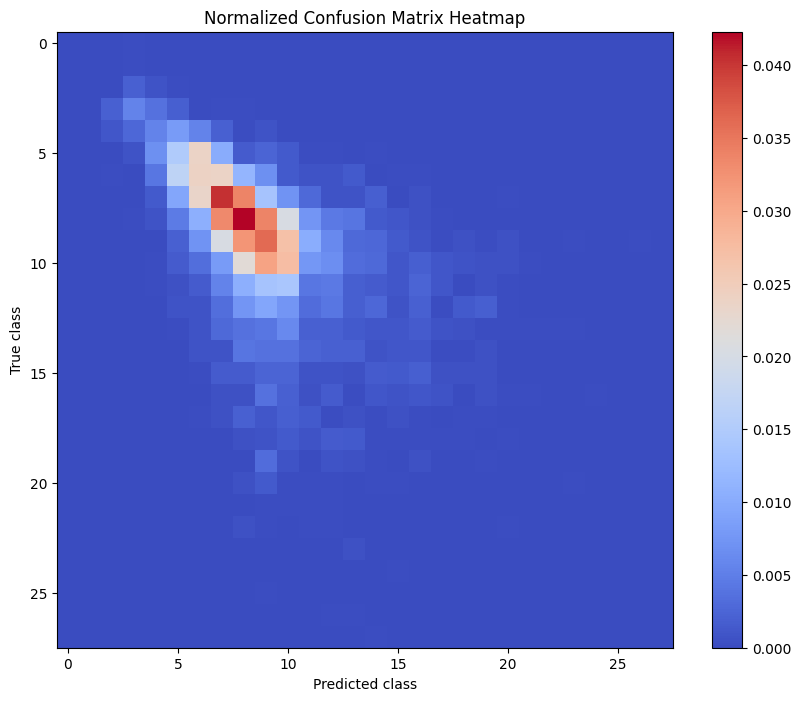

```python
kf = KFold(n_splits=5, shuffle=True, random_state=42)

# initialize performance metrics
accuracies = []
confusion_matrices = []
count = 1

N = 5
n_features = 30

# iterate over each fold
for train_index, test_index in kf.split(X_train_numpy, y_train_numpy):
    # split data into training and testing sets
    X_train, X_test = X_train_numpy[train_index], X_train_numpy[test_index]
    y_train, y_test = y_train_numpy[train_index], y_train_numpy[test_index]

    # build random forest
    rdf = build_rdf(X_train, y_train, attribute_types, N, options=n_features)

    # make predictions on the test set
    y_pred = predict_rdf(rdf, X_test)

    # calculate accuracy
    accuracy = accuracy_score(y_test, y_pred)
    accuracies.append(accuracy)

    # calculate confusion matrix
    conf_matrix = confusion_matrix(y_test, y_pred, labels=np.unique(np.array(y)))
    confusion_matrices.append(conf_matrix)

    print(f"Fold {count} is completed")
    count += 1



# calculate average accuracy
average_accuracy = np.mean(accuracies)

# calculate average confusion matrix and normalized version
average_conf_matrix = np.mean(confusion_matrices, axis=0)

normalized_conf_matrix = average_conf_matrix / np.sum(average_conf_matrix)

# print the result
print(f'Average Accuracy: {average_accuracy:.2f}')

# create a heatmap for the normalized confusion matrix
plt.figure(figsize=(10, 8))

cmap = plt.get_cmap('coolwarm')
heatmap = plt.imshow(normalized_conf_matrix, cmap=cmap)
plt.colorbar(heatmap)
plt.xlabel('Predicted class')
plt.ylabel('True class')
plt.title('Normalized Confusion Matrix Heatmap')

# show the plot
plt.show()
```

There is no big difference between the N=5 and N=10 test cases. We can try to increase the number of features.

Test with 5-fold. Number of feature is 50%. Number of trees is 10

```
Number of features: 4
Number of features: 4
Number of features: 4
Number of features: 4
Number of features: 4
Number of features: 4
Number of features: 4
Number of features: 4
Number of features: 4
Number of features: 4
Fold 1 is completed
Number of features: 4
Number of features: 4
Number of features: 4
Number of features: 4
Number of features: 4
Number of features: 4
Number of features: 4
Number of features: 4
Number of features: 4
Number of features: 4
Fold 2 is completed
Number of features: 4
Number of features: 4
Number of features: 4
Number of features: 4
Number of features: 4
Number of features: 4
Number of features: 4
Number of features: 4
Number of features: 4
Number of features: 4
Fold 3 is completed
Number of features: 4
Number of features: 4
Number of features: 4
Number of features: 4
Number of features: 4
Number of features: 4
Number of features: 4
Number of features: 4
Number of features: 4
Number of features: 4
Fold 4 is completed
Number of features: 4
Number of features: 4
Number of features: 4
Number of features: 4
Number of features: 4
Number of features: 4
Number of features: 4
Number of features: 4
Number of features: 4
Number of features: 4
Fold 5 is completed
Average Accuracy: 0.22
```

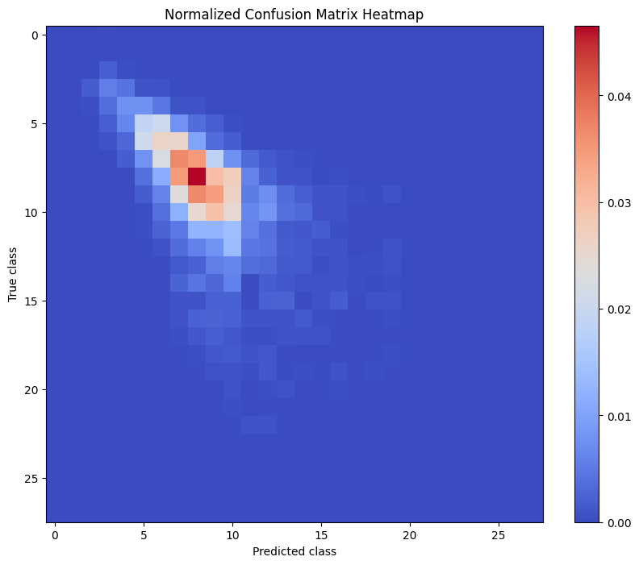

```python
kf = KFold(n_splits=5, shuffle=True, random_state=42)

# initialize performance metrics
accuracies = []
confusion_matrices = []
count = 1

N = 10
n_features = 50

# iterate over each fold
for train_index, test_index in kf.split(X_train_numpy, y_train_numpy):
    # split data into training and testing sets
    X_train, X_test = X_train_numpy[train_index], X_train_numpy[test_index]
    y_train, y_test = y_train_numpy[train_index], y_train_numpy[test_index]

    # build random forest
    rdf = build_rdf(X_train, y_train, attribute_types, N, options=n_features)

    # make predictions on the test set
    y_pred = predict_rdf(rdf, X_test)

    # calculate accuracy
    accuracy = accuracy_score(y_test, y_pred)
    accuracies.append(accuracy)

    # calculate confusion matrix
    conf_matrix = confusion_matrix(y_test, y_pred, labels=np.unique(np.array(y)))
    confusion_matrices.append(conf_matrix)

    print(f"Fold {count} is completed")
    count += 1



# calculate average accuracy
average_accuracy = np.mean(accuracies)

# calculate average confusion matrix and normalized version
average_conf_matrix = np.mean(confusion_matrices, axis=0)

normalized_conf_matrix = average_conf_matrix / np.sum(average_conf_matrix)

# print the result
print(f'Average Accuracy: {average_accuracy:.2f}')

# create a heatmap for the normalized confusion matrix
plt.figure(figsize=(10, 8))

cmap = plt.get_cmap('coolwarm')
heatmap = plt.imshow(normalized_conf_matrix, cmap=cmap)
plt.colorbar(heatmap)
plt.xlabel('Predicted class')
plt.ylabel('True class')
plt.title('Normalized Confusion Matrix Heatmap')

# show the plot
plt.show()
```

We can't see a huge difference between these test cases.

Result : We can't tell anything about the efficiency of these models. The dataset suffers from imbalance problem and this affects the result. The imbalance is seen in the confusion matrices as well. However, the best performance belongs to pre-pruning decision tree among all of them.

# Use Another Labelling for the Dataset

We will divide classes into 3 groups. The first group will be young class (1), the second will be medium class (2), and the third one will be old class (3).

```python
class_mapping = {
    # Young classes (0-9)
    1: 1,
    2: 1,
    3: 1,
    4: 1,
    5: 1,
    6: 1,
    7: 1,
    8: 1,
    9: 1,

    # Medium classes (10-19)
    10: 2,
    11: 2,
    12: 2,
    13: 2,
    14: 2,
    15: 2,
    16: 2,
    17: 2,
    18: 2,
    19: 2,

    # Old classes (20-29)
    20: 3,
    21: 3,
    22: 3,
    23: 3,
    24: 3,
    25: 3,
    26: 3,
    27: 3,
    28: 3,
    29: 3
}

y_grouped = [class_mapping[label] for label in y]

label_distribution = Counter(y_grouped)
print(label_distribution)
```

```
Counter({1: 2096, 2: 2019, 3: 62})
```

We can see that there is still a class imbalance problem with the old class. This will decrease the accuracy for old class but as an average, it will give a better accuracy.

We can try this dataset for the best models in the previous section: prepruning DT with max depth = 5 and RDF with N = 10 and number of features = 30%

```
Number of features: 8
Fold 1 is completed
Number of features: 8
Fold 2 is completed
Number of features: 8
Fold 3 is completed
Number of features: 8
Fold 4 is completed
Number of features: 8
Fold 5 is completed
Average Accuracy: 0.76
```

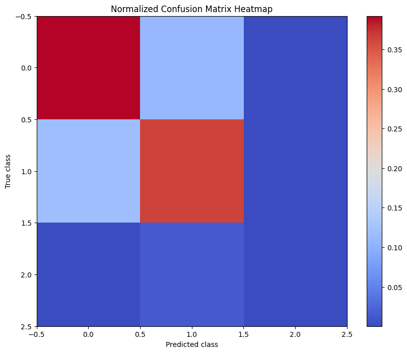

```python
kf = KFold(n_splits=5, shuffle=True, random_state=42)

# initialize performance metrics
accuracies = []
confusion_matrices = []
count = 1

X_num = np.array(X)
y_num = np.array(y_grouped)
# iterate over each fold
for train_index, test_index in kf.split(X_num, y_num):
    # split data into training and testing sets
    X_train, X_test = X_num[train_index], X_num[test_index]
    y_train, y_test = y_num[train_index], y_num[test_index]

    # create a decision tree and build
    dt = build_dt(X_train, y_train, attribute_types, options=(1, 5, None, None, None))

    # make predictions on the test set
    y_pred = predict_dt(dt, X_test)

    # calculate accuracy
    accuracy = accuracy_score(y_test, y_pred)
    accuracies.append(accuracy)

    # calculate confusion matrix
    conf_matrix = confusion_matrix(y_test, y_pred, labels=np.unique(np.array(y_num)))
    confusion_matrices.append(conf_matrix)

    print(f"Fold {count} is completed")
    count += 1


# calculate average accuracy
average_accuracy = np.mean(accuracies)

# calculate average confusion matrix and normalized version
average_conf_matrix = np.mean(confusion_matrices, axis=0)

normalized_conf_matrix = average_conf_matrix / np.sum(average_conf_matrix)

# print the result
print(f'Average Accuracy: {average_accuracy:.2f}')

# create a heatmap for the normalized confusion matrix
plt.figure(figsize=(10, 8))

cmap = plt.get_cmap('coolwarm')
heatmap = plt.imshow(normalized_conf_matrix, cmap=cmap)
plt.colorbar(heatmap)
plt.xlabel('Predicted class')
plt.ylabel('True class')
plt.title('Normalized Confusion Matrix Heatmap')

# show the plot
plt.show()
```

We can see that the accuracy is much better for this labelling but old class is not that high because the data amount is not sufficient.

```
Number of features: 2
Number of features: 2
Number of features: 2
Number of features: 2
Number of features: 2
Number of features: 2
Number of features: 2
Number of features: 2
Number of features: 2
Number of features: 2
Fold 1 is completed
Number of features: 2
Number of features: 2
Number of features: 2
Number of features: 2
Number of features: 2
Number of features: 2
Number of features: 2
Number of features: 2
Number of features: 2
Number of features: 2
Fold 2 is completed
Number of features: 2
Number of features: 2
Number of features: 2
Number of features: 2
Number of features: 2
Number of features: 2
Number of features: 2
Number of features: 2
Number of features: 2
Number of features: 2
Fold 3 is completed
Number of features: 2
Number of features: 2
Number of features: 2
Number of features: 2
Number of features: 2
Number of features: 2
Number of features: 2
Number of features: 2
Number of features: 2
Number of features: 2
Fold 4 is completed
Number of features: 2
Number of features: 2
Number of features: 2
Number of features: 2
Number of features: 2
Number of features: 2
Number of features: 2
Number of features: 2
Number of features: 2
Number of features: 2
Fold 5 is completed
Average Accuracy: 0.75
```

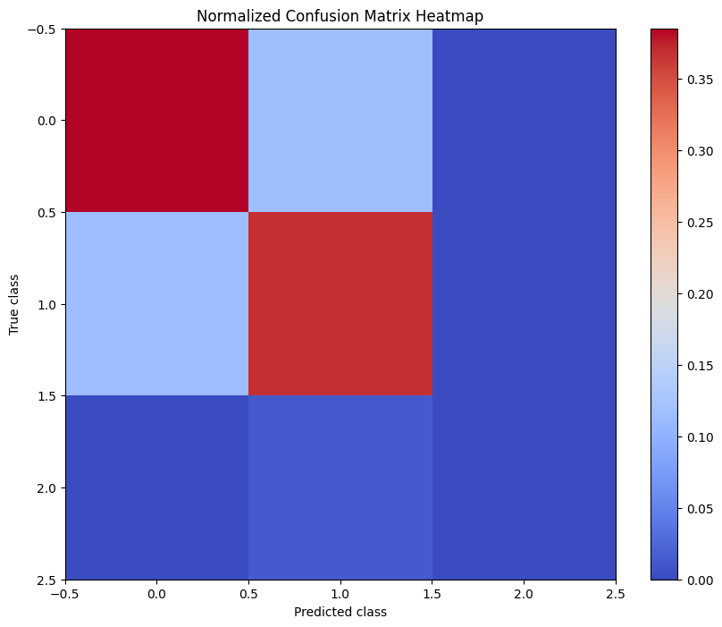

```python
kf = KFold(n_splits=5, shuffle=True, random_state=42)

# initialize performance metrics
accuracies = []
confusion_matrices = []
count = 1

N = 10
n_features = 30

# iterate over each fold
for train_index, test_index in kf.split(X_num, y_num):
    # split data into training and testing sets
    X_train, X_test = X_num[train_index], X_num[test_index]
    y_train, y_test = y_num[train_index], y_num[test_index]

    # build random forest
    rdf = build_rdf(X_train, y_train, attribute_types, N, options=n_features)

    # make predictions on the test set
    y_pred = predict_rdf(rdf, X_test)

    # calculate accuracy
    accuracy = accuracy_score(y_test, y_pred)
    accuracies.append(accuracy)

    # calculate confusion matrix
    conf_matrix = confusion_matrix(y_test, y_pred, labels=np.unique(np.array(y_num)))
    confusion_matrices.append(conf_matrix)

    print(f"Fold {count} is completed")
    count += 1



# calculate average accuracy
average_accuracy = np.mean(accuracies)

# calculate average confusion matrix and normalized version
average_conf_matrix = np.mean(confusion_matrices, axis=0)

normalized_conf_matrix = average_conf_matrix / np.sum(average_conf_matrix)

# print the result
print(f'Average Accuracy: {average_accuracy:.2f}')

# create a heatmap for the normalized confusion matrix
plt.figure(figsize=(10, 8))

cmap = plt.get_cmap('coolwarm')
heatmap = plt.imshow(normalized_conf_matrix, cmap=cmap)
plt.colorbar(heatmap)
plt.xlabel('Predicted class')
plt.ylabel('True class')
plt.title('Normalized Confusion Matrix Heatmap')

# show the plot
plt.show()
```

This result is similar to the one for prepruning DT. We can say that this labelling works better but overall, there is a problem with class distribution and this affects the accuracy a lot.